# Machine Learning Project Plus

Winston Saunders

Dec 2014

### Summary

Project for the Coursera “Machine Learning” course taught by Roger Peng, Jeff Leek, and Brian Caffo of the Dept of Statistics of the Bloomberg School at Johns Hopkins University.

The data used for this project have been generously provided by [Groupware Brasil](http://groupware.les.inf.puc-rio.br/har#ixzz3M5OnVvGE).

*Velloso, E.; Bulling, A.; Gellersen, H.; Ugulino, W.; Fuks, H. Qualitative Activity Recognition of Weight Lifting Exercises. Proceedings of 4th International Conference in Cooperation with SIGCHI (Augmented Human ’13) . Stuttgart, Germany: ACM SIGCHI, 2013.*

The comprise motion measurements of different subjects doing a weight-lifting activity both correctly and incorrectly. The point of the exercise is to build a model from a test data set. Cross correlate the model to ensure it is not over-trained, and then apply it to make predictions of motion classification on a test data set.

### A: Getting and cleaning data

The raw training set consists of 3927 rows and 160 columns.

Inspection reveals there are many NA values in the data. A historgram shows that there are really two classes of columns. Those with data and those without. To filter them I choose to eliminate those columns with high numbers (arbitrarily picked >50%) of NA values.  
The cleaning also includes steps to eliminate non-data columns like timestamps, etc.

Here is a look at the somecolumns of the raw data, showing both relevant and non-relevant data.

```r
        Ctraining[1:3, c(5, 8, 12, 30, 41)]
```

```
##     cvtd_timestamp roll_belt gyros_belt_x accel_arm_z accel_dumbbell_x
## 2 05/12/2011 11:23      1.41         0.02        -125             -233
## 5 05/12/2011 11:23      1.48         0.02        -123             -233
## 8 05/12/2011 11:23      1.42         0.02        -124             -234
```

Cleaning reduces the number of data columns from 160 to 53. The testing data also is reduced to 53 columns as expected.

### B: Data Exploration

Here we look into the data to understand its behavior. However, since we want to cross validate the data prior to making predictions, I first divide the training set.

#### B.1: Dividing the Test Data into a training and test subsets for cross validation

Use the caret package to create a data partition with 60% of the data in the training set and 40% in the test set.

```r
        inTrain <- createDataPartition(y=Ctraining$classe, p=0.60, list=FALSE)
        Train <- Ctraining[inTrain,]
        Test <- Ctraining[-inTrain,]
```

#### B.2: Plot a few dependencies to get an idea of what the data look like

I plot a few columns of the data just to see what we are dealing with. In general is it hard to see strong dependencies of any particular variable (though in some cases they are recognized). There are clear differences in some cases between the plots and not in others.

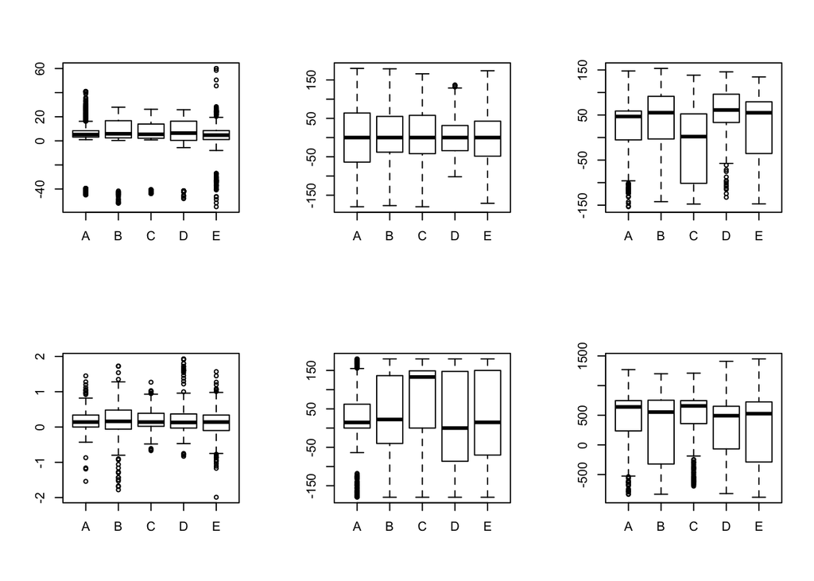

### C: Building a Model

When all else fails, build a model and see what you get.

Model the training data using the random forest technique. I played around with the parameters a bit to optimize execution. For instance using model type cv seemed to increase speed a bit and produce what I felt was a better confusion matrix. Method “boot” tended to skew the error a bit. I’m unclear on the allow parallel but when I saw it in the documentation I used it since I have a multicore processor.  
I experimented with the number variable. Using *number = 3* decreased the user time about 25% from *number = 4*, without a noticable reduction in accuracy.

```r
        control1 <- trainControl(method = "cv", number = 3, allowParallel = TRUE)
        model1 <- train(classe~., data = Train, method="rf", trControl = control1, prox=TRUE)
```

[output not shown]

[figure not shown]

A cross validation with the testing data subsetted from the original training data shows the model is very accurate. The confusion matrix is below.

```r
        prediction1 <- predict(model1, Test)
        confusionMatrix(Test$classe, prediction1)
```

```
## Confusion Matrix and Statistics
##
##           Reference
## Prediction   A   B   C   D   E
##          A 436   1   5   4   0
##          B  11 280  12   1   0
##          C   0  14 256   4   0
##          D   1   0  14 237   5
##          E   0   0   2   2 284
##
## Overall Statistics
##
##                Accuracy : 0.9516
##                  95% CI : (0.9397, 0.9616)
##     No Information Rate : 0.2855
##     P-Value [Acc > NIR] : < 2.2e-16
##
##                   Kappa : 0.9387
##  Mcnemar's Test P-Value : NA
##
## Statistics by Class:
##
##                      Class: A Class: B Class: C Class: D Class: E
## Sensitivity            0.9732   0.9492   0.8858   0.9556   0.9827
## Specificity            0.9911   0.9812   0.9859   0.9849   0.9969
## Pos Pred Value         0.9776   0.9211   0.9343   0.9222   0.9861
## Neg Pred Value         0.9893   0.9881   0.9745   0.9916   0.9961
## Prevalence             0.2855   0.1880   0.1842   0.1581   0.1842
## Detection Rate         0.2779   0.1785   0.1632   0.1511   0.1810
## Detection Prevalence   0.2843   0.1938   0.1746   0.1638   0.1836
## Balanced Accuracy      0.9821   0.9652   0.9359   0.9703   0.9898
```

For information this calculation took 90.317 seconds of elapsed time and 0.862 seconds of system time on a *MacBook Air*. Every time I ran it my battery level dropped about 5%!!!

### D. Using the model to make Predictions

We can use the model to make predictions on the testing data set from the exercise. The model makes all predictions accurately.

I use the funciton provided in class to create answer files.

```r
        answers<-predict(model1, Ctesting)
```

```
##  [1] B A B A A E D B A A B C B A E E A B B B
## Levels: A B C D E
```

### Conclusions

Using data from the HAR dataset we are able to identify with high accuracy the type of activity undertaken using a [Random Forest](http://en.wikipedia.org/wiki/Random_forest) model.